# Assignment_MA

Akshita

2024-03-28

```r
social_media <- read.csv("C:/Users/HP/Downloads/Social_media_original.csv")
str(social_media)
```

```
## 'data.frame':    21 obs. of  25 variables:
##  $ Enter.5.character.id...not.your.net.id..or.your.name...It.should.be.same.throughout.the.survey.: chr  "masinl" "peace" "Patty" "Bunny" ...
##  $ Instagram                                                                                      : chr  "Yes" "Yes" "Yes" "Yes" ...
##  $ Hours.spent..HH.MM..Input.N.A.if.not.a.user                                                    : chr  "3.5" "7:44" "3:46" "5:23" ...
##  $ Linkedin                                                                                       : chr  "Yes" "Yes" "Yes" "Yes" ...
##  $ Hours.spent..HH.MM..Input.N.A.if.not.a.user.1                                                  : chr  "4" "5:12" "7:00" "5:19" ...
##  $ Snapchat                                                                                       : chr  "Yes" "Yes" "Yes" "Yes" ...
##  $ Hours.spent..HH.MM..Input.N.A.if.not.a.user.2                                                  : chr  "1" "3:41" "0:32" "1:18" ...
##  $ Twitter                                                                                        : chr  "Yes" "No" "No" "No" ...
##  $ Hours.spent..HH.MM..Input.N.A.if.not.a.user.3                                                  : chr  "5" "0:00" "N/A" "N/A" ...
##  $ Whatsapp..Wechat                                                                               : chr  "Yes" "Yes" "Yes" "Yes" ...
##  $ Hours.spent..HH.MM..Input.N.A.if.not.a.user.4                                                  : chr  "1" "4:11" "9:50" "5:18" ...
##  $ Youtube                                                                                        : chr  "Yes" "Yes" "Yes" "Yes" ...
##  $ Hours.spent..HH.MM..Input.N.A.if.not.a.user.5                                                  : chr  "2.5" "4:15" "1:51" "2:00" ...
##  $ OTT..Netflix..Hulu..Prime.video..                                                              : chr  "Yes" "No" "Yes" "Yes" ...
##  $ Hours.spent..HH.MM..Input.N.A.if.not.a.user.6                                                  : chr  "14.5" "0:00" "2:00" "2:00" ...
##  $ Reddit                                                                                         : chr  "Yes" "No" "No" "No" ...
##  $ Hours.spent..HH.MM..Input.N.A.if.not.a.user.7                                                  : chr  "2.5" "0:00" "N/A" "N.A" ...
##  $ Application.type.Social.media..OTT..Learning.                                                  : chr  "OTT" "Social Media" "Social Media" "Social Media" ...
##  $ How.many.job.interview.calls.received.in.this.week..                                           : chr  "N/A" "0" "0" "2" ...
##  $ How.much.networking.done.with.coffee.chats.                                                    : chr  "N/A" "1" "0" "0" ...
##  $ How.many.learning.done.in.terms.of.items.created.                                              : num  3 3 4 4 4 4 3 2 6 2 ...
##  $ Mood.Productivity                                                                              : chr  "Yes" "Yes" "Yes" "Yes" ...
##  $ Tired.waking.up.in.morning                                                                     : chr  "No" "No" "No" "No" ...
##  $ Trouble.falling.asleep                                                                         : chr  "No" "Yes" "No" "No" ...
##  $ How.you.felt.the.entire.week.                                                                  : int  3 3 4 4 3 5 4 4 3 2 ...
```

```r
social_media_cleaned <- social_media[,-1]

#changing column names
change_cols_index <- c(2,4,6,8,10,12,14,16,17,18,19,20,21,22,23,24)
change_cols_name <- c("Instagram_Time", "Linkedin_Time", "Snapchat_Time", "Twitter_Time", "Whatsapp_Time", "Youtube_Time", "OTT_Time", "Reddit_Time", "Application Type", "Interview_call_received", "Networking", "Learning", "Mood_Productivity", "Morning_tireness", "Sleep_trouble", "Weekly_Feelings")
colnames(social_media_cleaned)[change_cols_index] <- change_cols_name


# Convert "NA", "N/A", "n/a", "na", "N.A", "n.a" to 0
social_media_cleaned[social_media_cleaned == "NA" | social_media_cleaned == "N/A" | social_media_cleaned == "na" | social_media_cleaned == "n/a" | social_media_cleaned == "N.A" | social_media_cleaned == "n.a" | social_media_cleaned == "0" | social_media_cleaned == ""] <- NA
social_media_cleaned[is.na(social_media_cleaned)] <- 0

# Define a function to convert time strings to decimal hours
convert_to_decimal_hours <- function(time_string) {
# Check if NA values are present
if (any(is.na(time_string))) {
         return(rep(NA, length(time_string)))  # Return NA for NA values
     }

# Define a function to convert HH:MM format to decimal hours
     hhmm_to_decimal <- function(hhmm) {
         parts <- as.numeric(strsplit(hhmm, ":")[[1]])  # Split into hours and minutes
         hours <- parts[1]
         minutes <- ifelse(length(parts) > 1, parts[2], 0)  # Handle missing minutes
         total_hours <- hours + minutes / 60
         return(total_hours)
     }

# Convert time strings to decimal hours
decimal_hours <- sapply(time_string, function(x) {
         if (grepl("^\\d+:\\d+$", x)) {
             return(hhmm_to_decimal(x))  # Convert HH:MM format
         } else if (grepl("^\\d+\\.\\d+$", x)) {
             return(as.numeric(x))  # Convert decimal format
         } else if (grepl("^\\d+$", x)) {
             return(as.numeric(x))  # Convert whole numbers
         } else {
             return(NA)  # Return NA for other cases
         }
     })

     return(decimal_hours)
}

time_columns <- c("Instagram_Time", "Linkedin_Time", "Snapchat_Time", "Twitter_Time", "Whatsapp_Time", "Youtube_Time", "OTT_Time", "Reddit_Time")
# Apply the conversion function to all time columns
social_media_cleaned[time_columns] <- lapply(social_media_cleaned[time_columns], convert_to_decimal_hours)

# Verify the result
str(social_media_cleaned)
```

```
## 'data.frame':    21 obs. of  24 variables:
##  $ Instagram                        : chr  "Yes" "Yes" "Yes" "Yes" ...
##  $ Instagram_Time                   : num  3.5 7.73 3.77 5.38 0 ...
##  $ Linkedin                         : chr  "Yes" "Yes" "Yes" "Yes" ...
##  $ Linkedin_Time                    : num  4 5.2 7 5.317 0.583 ...
##  $ Snapchat                         : chr  "Yes" "Yes" "Yes" "Yes" ...
##  $ Snapchat_Time                    : num  1 3.683 0.533 1.3 0 ...
##  $ Twitter                          : chr  "Yes" "No" "No" "No" ...
##  $ Twitter_Time                     : num  5 0 0 0 0.667 ...
##  $ Whatsapp..Wechat                 : chr  "Yes" "Yes" "Yes" "Yes" ...
##  $ Whatsapp_Time                    : num  1 4.18 9.83 5.3 3 ...
##  $ Youtube                          : chr  "Yes" "Yes" "Yes" "Yes" ...
##  $ Youtube_Time                     : num  2.5 4.25 1.85 2 3.5 7 3 2 4 3 ...
##  $ OTT..Netflix..Hulu..Prime.video..: chr  "Yes" "No" "Yes" "Yes" ...
##  $ OTT_Time                         : num  14.5 0 2 2 2 3 0 3 3 0 ...
##  $ Reddit                           : chr  "Yes" "No" "No" "No" ...
##  $ Reddit_Time                      : num  2.5 0 0 0 1 0 0 0 0 0 ...
##  $ Application Type                 : chr  "OTT" "Social Media" "Social Media" "Social Media" ...
##  $ Interview_call_received          : chr  "0" "0" "0" "2" ...
##  $ Networking                       : chr  "0" "1" "0" "0" ...
##  $ Learning                         : num  3 3 4 4 4 4 3 2 6 2 ...
##  $ Mood_Productivity                : chr  "Yes" "Yes" "Yes" "Yes" ...
##  $ Morning_tireness                 : chr  "No" "No" "No" "No" ...
##  $ Sleep_trouble                    : chr  "No" "Yes" "No" "No" ...
##  $ Weekly_Feelings                  : int  3 3 4 4 3 5 4 4 3 2 ...
```

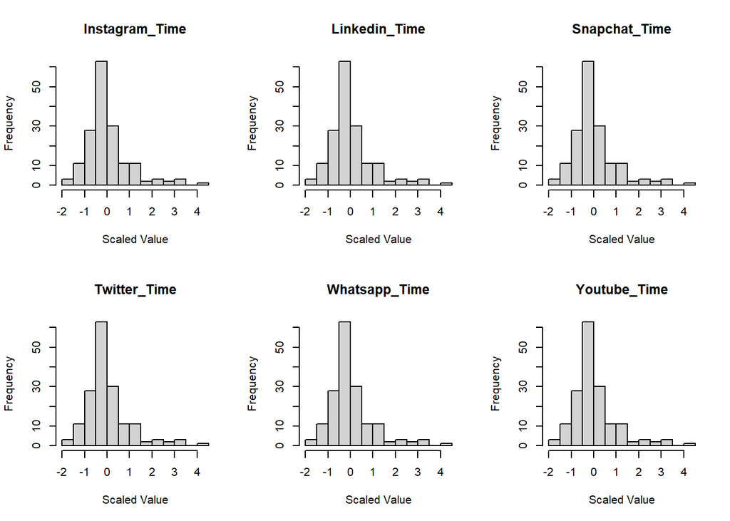

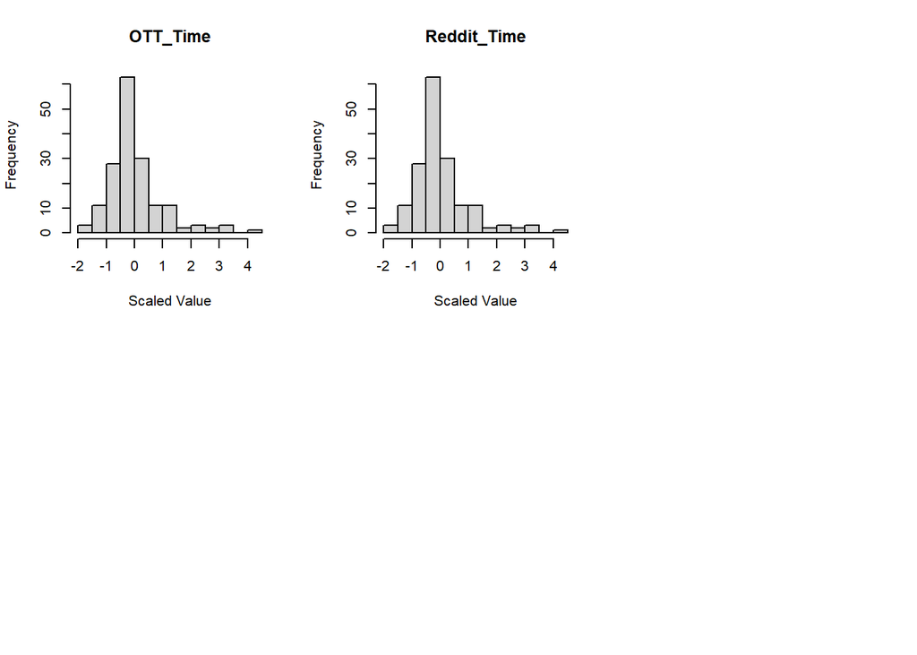

```r
#Dropping the name columns
social_media_cleaned <- social_media_cleaned[, -c(1, 3, 5, 7, 9, 11, 13, 15)]

#Treating NA in whatsapp column
mean_value <- mean(social_media_cleaned$Whatsapp_Time, na.rm = TRUE)
social_media_cleaned$Whatsapp_Time[is.na(social_media_cleaned$Whatsapp_Time)] <- mean_value

#Scaling the data
# Extracting the columns with names ending in "_Time"
time_columns <- grep("_Time$", names(social_media_cleaned), value = TRUE)

# Scaling the time columns
scaled_time_data <- scale(social_media_cleaned[time_columns])

#plotting the scaled values
x_time_columns <- grep("_Time$", names(social_media_cleaned), value = TRUE)

# Plot histograms for each x_time column
par(mfrow = c(2, 3))  # Adjust the layout based on the number of x_time columns
for (col in x_time_columns) {
    hist(scaled_time_data, main = col, xlab = "Scaled Value")
}
```

```r
#distance of my social media usage and class average
# Calculate the Mahalanobis distance manually
my_usage <- as.matrix(scaled_time_data[12, ])
class_mean <- colMeans(scaled_time_data)
class_cov <- cov(scaled_time_data)
diff <- my_usage - class_mean
maha_dist <- sqrt(t(diff) %*% solve(class_cov) %*% diff)

# Print the Mahalanobis distance
print(maha_dist)
```

```
##          [,1]
## [1,] 2.965306
```

```r
#PCA

# Compute the covariance matrix
cov_matrix <- cov(scaled_time_data)

# Perform eigenvalue decomposition
eigen_result <- eigen(cov_matrix)

# Extract eigenvalues and eigenvectors
eigenvalues <- eigen_result$values
eigenvectors <- eigen_result$vectors

#To find number of principal components to consider:
#1 Eigenvalue criterion
eigenvalues <- eigen_result$values
num_components <- sum(eigenvalues > 1)
print(num_components)
```

```
## [1] 3
```

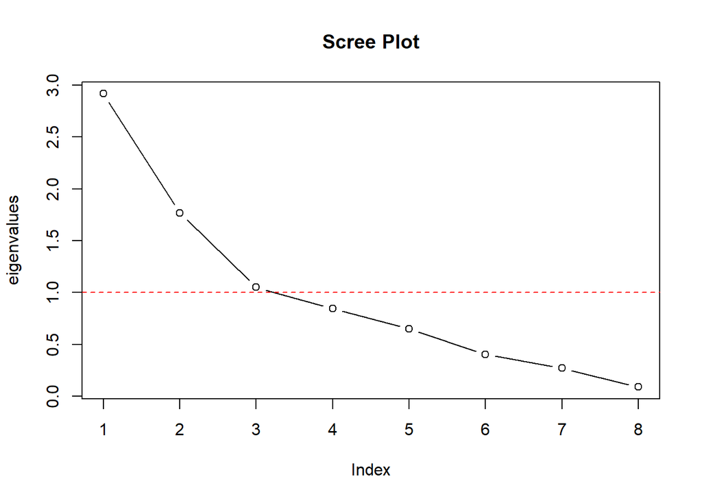

```r
#2 Scree plot
plot(eigenvalues, type = "b", main = "Scree Plot")
abline(h = 1, col = "red", lty = 2)
```

```r
#Retaining 3 PC
n_components <- 3
transformed_data <- scaled_time_data %*% eigenvectors[, 1:n_components]
print(transformed_data)
```

```
##              [,1]        [,2]        [,3]
##  [1,]  1.00370712  5.02662032  0.09658468
##  [2,] -1.16666311 -0.45260979  0.02142196
##  [3,] -0.31114405 -0.64233982  0.36231498
##  [4,] -0.02555084 -0.35515602 -0.14000483
##  [5,]  1.84296392  0.01403488  0.57321255
##  [6,] -1.43145371 -0.67449037  2.16751047
##  [7,]  0.34658392 -0.91791132  0.23242107
##  [8,] -1.09290545 -0.27947874 -0.86035444
##  [9,] -2.37182368  0.11604821  0.54691672
## [10,]  2.20623543 -0.78857489  0.09266100
## [11,]  1.96115852  0.54004312 -0.89849487
## [12,]  1.48286624  0.83783681 -0.29595929
## [13,]  1.23163752 -0.67716098 -1.09606873
## [14,]  0.62603459 -0.03107607 -0.42499076
## [15,]  0.16397548  1.05909081  2.27165218
## [16,] -0.47045398 -0.52924139  0.96667372
## [17,] -0.80955326 -0.90907718 -0.69636214
## [18,]  0.14050230 -0.34775519 -1.37529108
## [19,] -0.44129821 -1.10416536  0.87902141
## [20,] -5.00561617  1.12757750 -1.57308667
## [21,]  2.12079744 -1.01221452 -0.84977794
```

PC2: This component represents additional variation orthogonal to PC1. Observations with higher values in PC2 but lower values in PC1 may have a unique combination of social media usage patterns compared to those with higher PC1 values.

PC3: Similar to PC2, PC3 captures additional variation orthogonal to PC1 and PC2. Observations with higher values in PC3 but lower values in PC1 and PC2 may exhibit yet another unique combination of social media usage patterns.

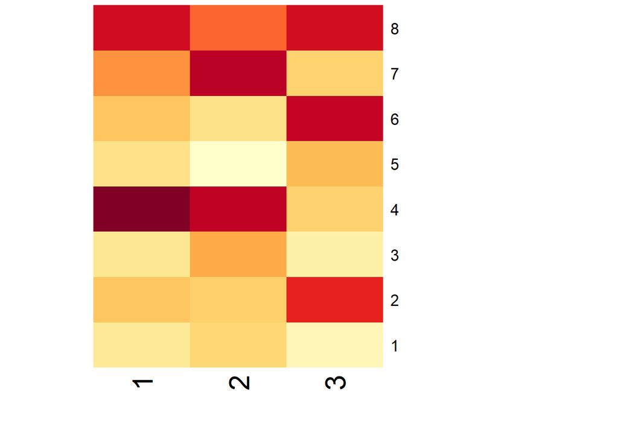

```r
library(RColorBrewer)
loadings <- eigenvectors[, 1:n_components]
my_palette <- colorRampPalette(brewer.pal(9, "YlOrRd"))
# Visualize the loadings matrix with the specified color palette
heatmap(loadings, Rowv = NA, Colv = NA, col = my_palette(256), scale = "column", margins = c(5, 10))
```

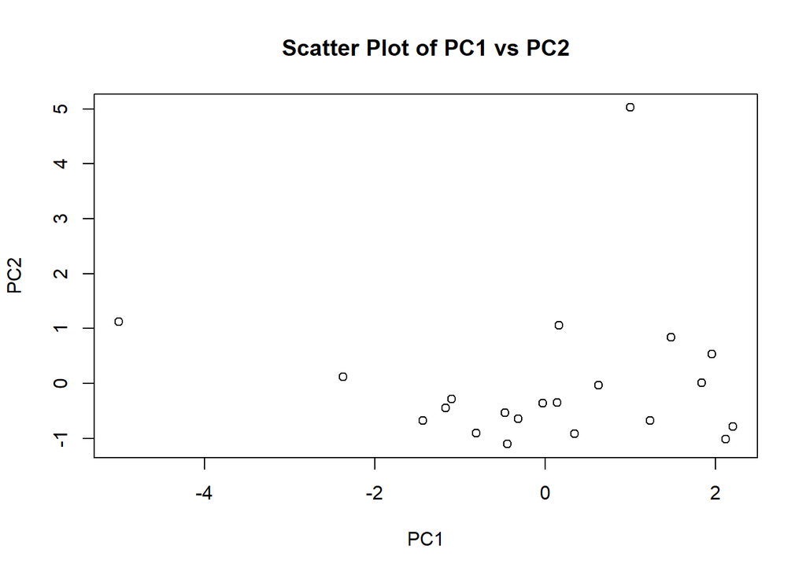

```r
# Scatter plot of the first two principal components
plot(transformed_data[, 1], transformed_data[, 2], xlab = "PC1", ylab = "PC2",
     main = "Scatter Plot of PC1 vs PC2")
```

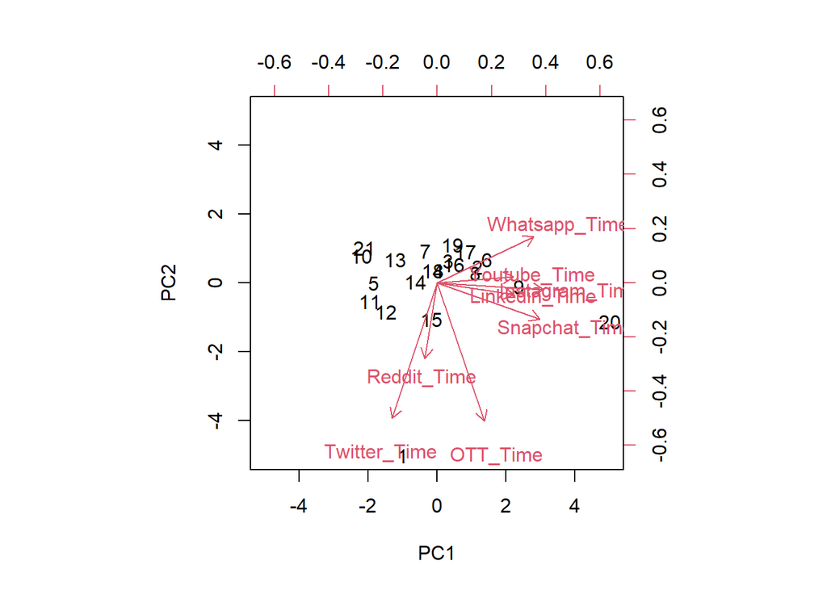

```r
biplot(prcomp(scaled_time_data), scale = 0)
```

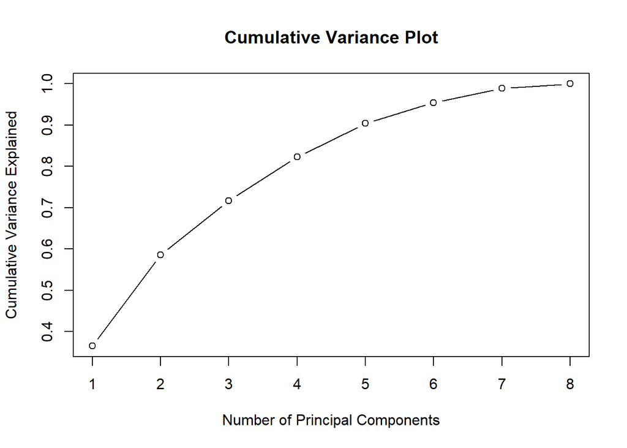

```r
# Cumulative Variance Plot
cumulative_variance <- cumsum(eigenvalues) / sum(eigenvalues)
plot(1:length(cumulative_variance), cumulative_variance, type = "b",
     xlab = "Number of Principal Components", ylab = "Cumulative Variance Explained",
     main = "Cumulative Variance Plot")
```

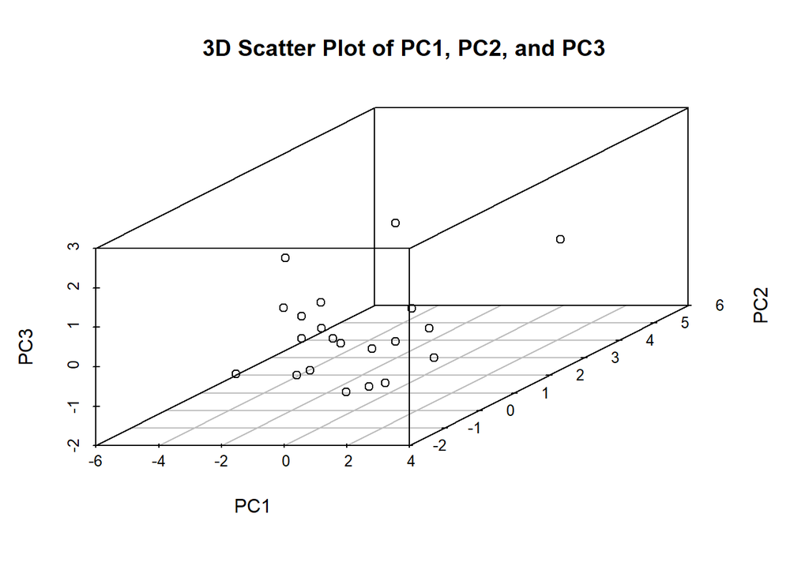

```r
# 3D Scatter Plot
library(scatterplot3d)
scatterplot3d(transformed_data[, 1], transformed_data[, 2], transformed_data[, 3],
              xlab = "PC1", ylab = "PC2", zlab = "PC3",
              main = "3D Scatter Plot of PC1, PC2, and PC3")
```

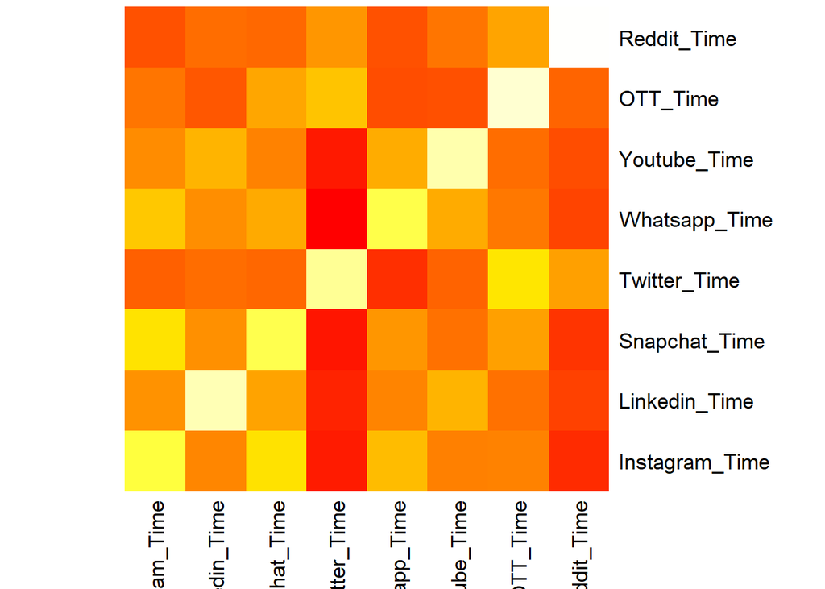

```r
# Heatmap of Correlation Matrix
corr_matrix <- cor(scaled_time_data)
heatmap(corr_matrix, Rowv = NA, Colv = NA, col = heat.colors(256))
```

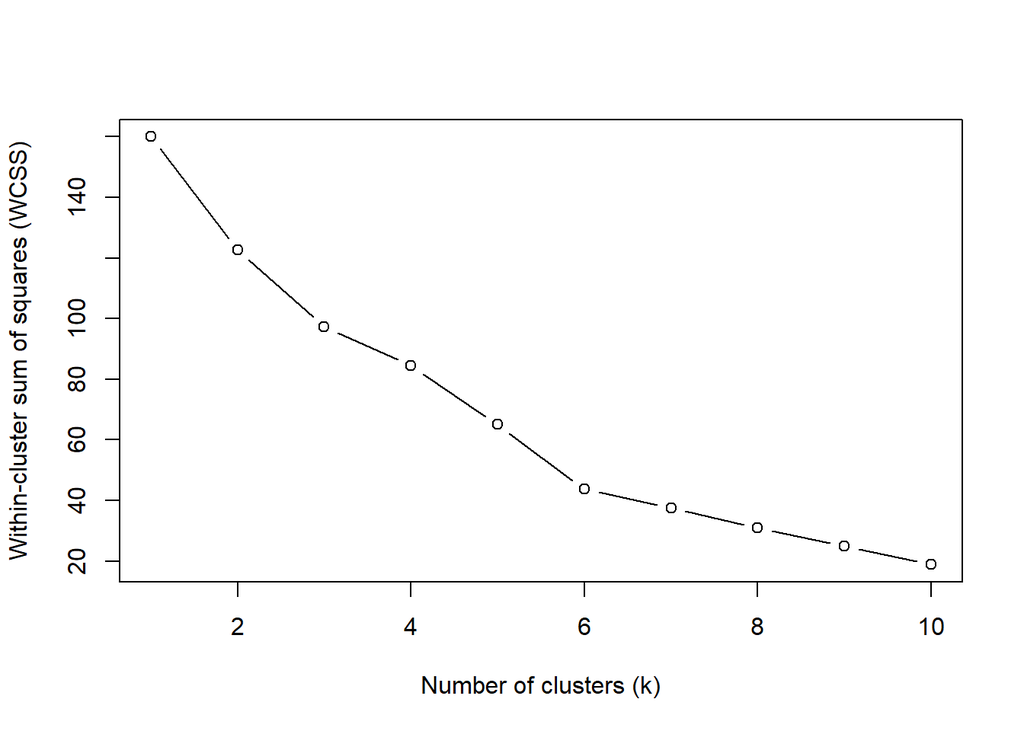

```r
#Cluster Analysis

# Define the maximum number of clusters to test
max_k <- 10

# Perform K-means clustering for different values of k
wcss <- numeric(length = max_k)
for (i in 1:max_k) {
  kmeans_model <- kmeans(scaled_time_data, centers = i)
  wcss[i] <- kmeans_model$tot.withinss
}

# Plot the elbow method
plot(1:max_k, wcss, type = "b", xlab = "Number of clusters (k)", ylab = "Within-cluster sum of squares (WCSS)")
```

```r
# Step 1: Choose the number of clusters (K)
K <- 6
# Step 2: Perform K-means clustering
kmeans_result <- kmeans(scaled_time_data, centers = K)
# Step 3: View cluster centers
print(kmeans_result$centers)
```

```
##   Instagram_Time Linkedin_Time Snapchat_Time Twitter_Time Whatsapp_Time
## 1     -0.2062930   -0.43612943   -0.39175925    1.1646684    -0.9087274
## 2      0.2193775    0.08167908   -0.07477155   -0.4199939     0.4857420
## 3      0.2677564    1.05009322    0.21156528   -0.4495103     0.2293722
## 4     -1.1292814   -1.19935594   -0.62728963   -0.3203760    -0.6854491
## 5      2.7975209    0.13169650    3.31254334   -0.4495103     2.2529688
## 6     -0.5359407    0.15189584   -0.16253261    3.4245185    -1.3320450
##   Youtube_Time   OTT_Time Reddit_Time
## 1   -0.5598100 -0.4326341  -0.3293296
## 2   -0.3693238 -0.1399591   0.2985977
## 3    1.2129444 -0.2721349  -0.2665369
## 4   -0.6977068 -0.4909036  -0.1701675
## 5    1.2628271  2.1636764  -0.3293296
## 6   -0.2720252  3.4382289   1.2404888
```

```r
# Step 4: View cluster assignments for each data point
print(kmeans_result$cluster)
```

```
##  [1] 6 3 2 2 4 3 2 2 3 4 1 1 4 1 2 3 2 2 3 5 4
```

```r
# Computing the percentage of variation accounted for. Two clusters
(kmeans2.sm <- kmeans(scaled_time_data,2,nstart = 10))
```

```
## K-means clustering with 2 clusters of sizes 11, 10
##
## Cluster means:
##   Instagram_Time Linkedin_Time Snapchat_Time Twitter_Time Whatsapp_Time
## 1      0.4959808     0.5993419     0.3150924   -0.4307272     0.6003270
## 2     -0.5455789    -0.6592760    -0.3466016    0.4737999    -0.6603597
##   Youtube_Time     OTT_Time Reddit_Time
## 1    0.5363885 -0.007354170  -0.3007875
## 2   -0.5900274  0.008089587   0.3308662
##
## Clustering vector:
##  [1] 2 1 1 1 2 1 1 1 1 2 2 2 2 2 2 1 1 2 1 1 2
##
## Within cluster sum of squares by cluster:
## [1] 59.05999 63.31822
##  (between_SS / total_SS =  23.5 %)
##
## Available components:
##
## [1] "cluster"      "centers"      "totss"        "withinss"     "tot.withinss"
## [6] "betweenss"    "size"         "iter"         "ifault"
```

```r
perc.var.2 <- round(100*(1 - kmeans2.sm$betweenss/kmeans2.sm$totss),1)
names(perc.var.2) <- "Perc. 2 clus"
perc.var.2
```

```
## Perc. 2 clus
##         76.5
```

```r
# Computing the percentage of variation accounted for. Three clusters
(kmeans3.sm <- kmeans(scaled_time_data,3,nstart = 10))
```

```
## K-means clustering with 3 clusters of sizes 1, 9, 11
##
## Cluster means:
##   Instagram_Time Linkedin_Time Snapchat_Time Twitter_Time Whatsapp_Time
## 1     -0.5359407     0.1518958    -0.1625326   3.42451853    -1.3320450
## 2      0.6046939     0.6396725     0.4640202  -0.42655312     0.7715887
## 3     -0.4460276    -0.5371771    -0.3648772   0.03767815    -0.5102049
##   Youtube_Time    OTT_Time Reddit_Time
## 1   -0.2720252  3.43822885   1.2404888
## 2    0.7160360  0.07666234  -0.2944448
## 3   -0.5611181 -0.37529000   0.1281377
##
## Clustering vector:
##  [1] 1 2 2 3 3 2 3 2 2 3 3 3 3 3 3 2 2 3 2 2 3
##
## Within cluster sum of squares by cluster:
## [1]  0.00000 53.15632 43.31722
##  (between_SS / total_SS =  39.7 %)
##
## Available components:
##
## [1] "cluster"      "centers"      "totss"        "withinss"     "tot.withinss"
## [6] "betweenss"    "size"         "iter"         "ifault"
```

```r
perc.var.3 <- round(100*(1 - kmeans3.sm$betweenss/kmeans2.sm$totss),1)
names(perc.var.3) <- "Perc. 3 clus"
perc.var.3
```

```
## Perc. 3 clus
##         60.3
```

```r
# Computing the percentage of variation accounted for. Four clusters
(kmeans4.sm <- kmeans(scaled_time_data,4,nstart = 10))
```

```
## K-means clustering with 4 clusters of sizes 1, 1, 11, 8
##
## Cluster means:
##   Instagram_Time Linkedin_Time Snapchat_Time Twitter_Time Whatsapp_Time
## 1     -0.5359407     0.1518958   -0.16253261    3.4245185    -1.3320450
## 2      2.7975209     0.1316965    3.31254334   -0.4495103     2.2529688
## 3      0.2231992     0.5919966    0.02001516   -0.4307272     0.3993301
## 4     -0.5895964    -0.8494444   -0.42127218    0.2203738    -0.6641943
##   Youtube_Time   OTT_Time Reddit_Time
## 1   -0.2720252  3.4382289  1.24048879
## 2    1.2628271  2.1636764 -0.32932963
## 3    0.4299953 -0.2154882  0.09880266
## 4   -0.7150938 -0.4039419 -0.24974856
##
## Clustering vector:
##  [1] 1 3 3 3 4 3 3 3 3 4 4 4 4 4 3 3 3 4 3 2 4
##
## Within cluster sum of squares by cluster:
## [1]  0.00000  0.00000 52.45188 19.15592
##  (between_SS / total_SS =  55.2 %)
##
## Available components:
##
## [1] "cluster"      "centers"      "totss"        "withinss"     "tot.withinss"
## [6] "betweenss"    "size"         "iter"         "ifault"
```

```r
perc.var.4 <- round(100*(1 - kmeans4.sm$betweenss/kmeans4.sm$totss),1)
names(perc.var.4) <- "Perc. 4 clus"
perc.var.4
```

```
## Perc. 4 clus
##         44.8
```

```r
# Computing the percentage of variation accounted for. Five clusters
(kmeans5.sm <- kmeans(scaled_time_data,5,nstart = 10))
```

```
## K-means clustering with 5 clusters of sizes 1, 8, 1, 1, 10
##
## Cluster means:
##   Instagram_Time Linkedin_Time Snapchat_Time Twitter_Time Whatsapp_Time
## 1     -0.2030769    0.05089913    0.06669404   -0.4495103    0.04200212
## 2     -0.5895964   -0.84944443   -0.42127218    0.2203738   -0.66419432
## 3     -0.5359407    0.15189584   -0.16253261    3.4245185   -1.33204496
## 4      2.7975209    0.13169650    3.31254334   -0.4495103    2.25296879
## 5      0.2658268    0.64610639    0.01534727   -0.4288488    0.43506286
##   Youtube_Time   OTT_Time Reddit_Time
## 1   0.09250226 -0.1257974   4.0661619
## 2  -0.71509383 -0.4039419  -0.2497486
## 3  -0.27202515  3.4382289   1.2404888
## 4   1.26282710  2.1636764  -0.3293296
## 5   0.46374465 -0.2244572  -0.2979333
##
## Clustering vector:
##  [1] 3 5 5 5 2 5 5 5 5 2 2 2 2 2 1 5 5 2 5 4 2
##
## Within cluster sum of squares by cluster:
## [1]  0.00000 19.15592  0.00000  0.00000 34.33862
##  (between_SS / total_SS =  66.6 %)
##
## Available components:
##
## [1] "cluster"      "centers"      "totss"        "withinss"     "tot.withinss"
## [6] "betweenss"    "size"         "iter"         "ifault"
```

```r
perc.var.5 <- round(100*(1 - kmeans5.sm$betweenss/kmeans5.sm$totss),1)
names(perc.var.5) <- "Perc. 5 clus"
perc.var.5
```

```
## Perc. 5 clus
##         33.4
```

```r
# Computing the percentage of variation accounted for. Six clusters
(kmeans6.sm <- kmeans(scaled_time_data,6,nstart = 10))
```

```
## K-means clustering with 6 clusters of sizes 7, 5, 1, 1, 6, 1
##
## Cluster means:
##   Instagram_Time Linkedin_Time Snapchat_Time Twitter_Time Whatsapp_Time
## 1     -0.7337149   -0.87225886   -0.52634804    0.3160716   -0.78113982
## 2      0.2677564    1.05009322    0.21156528   -0.4495103    0.22937218
## 3     -0.2030769    0.05089913    0.06669404   -0.4495103    0.04200212
## 4     -0.5359407    0.15189584   -0.16253261    3.4245185   -1.33204496
## 5      0.2897865    0.08680907   -0.09834915   -0.4150745    0.55969865
## 6      2.7975209    0.13169650    3.31254334   -0.4495103    2.25296879
##   Youtube_Time   OTT_Time Reddit_Time
## 1  -0.63860817 -0.4659310  -0.2383798
## 2   1.21294440 -0.2721349  -0.2665369
## 3   0.09250226 -0.1257974   4.0661619
## 4  -0.27202515  3.4382289   1.2404888
## 5  -0.44629484 -0.1423194  -0.3293296
## 6   1.26282710  2.1636764  -0.3293296
##
## Clustering vector:
##  [1] 4 2 5 5 1 2 5 5 2 1 1 1 1 1 3 2 5 5 2 6 1
##
## Within cluster sum of squares by cluster:
## [1] 15.51660 15.35465  0.00000  0.00000 12.85219  0.00000
##  (between_SS / total_SS =  72.7 %)
##
## Available components:
##
## [1] "cluster"      "centers"      "totss"        "withinss"     "tot.withinss"
## [6] "betweenss"    "size"         "iter"         "ifault"
```

```r
perc.var.6 <- round(100*(1 - kmeans6.sm$betweenss/kmeans6.sm$totss),1)
names(perc.var.6) <- "Perc. 6 clus"
perc.var.6
```

```
## Perc. 6 clus
##         27.3
```

```r
attributes(perc.var.6)
```

```
## $names
## [1] "Perc. 6 clus"
```

```r
Variance_List <- c(perc.var.2,perc.var.3,perc.var.4,perc.var.5,perc.var.6)

Variance_List
```

```
## Perc. 2 clus Perc. 3 clus Perc. 4 clus Perc. 5 clus Perc. 6 clus
##         76.5         60.3         44.8         33.4         27.3
```

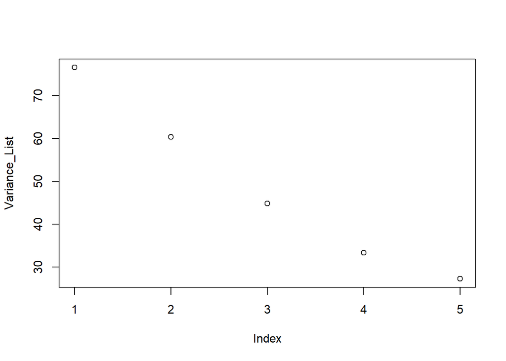

```r
plot(Variance_List)
```

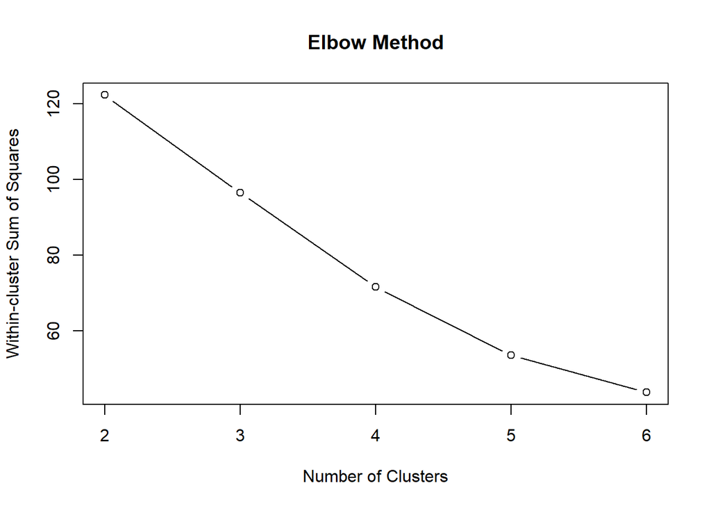

```r
#elbow method
# Perform K-means clustering for different numbers of clusters
wss <- numeric(length = 5)

for (k in 2:6) {
  kmeans_model <- kmeans(scaled_time_data, k, nstart = 10)
  wss[k - 1] <- kmeans_model$tot.withinss
}

#elbow curve
plot(2:6, wss, type = "b", xlab = "Number of Clusters", ylab = "Within-cluster Sum of Squares", main = "Elbow Method")
```

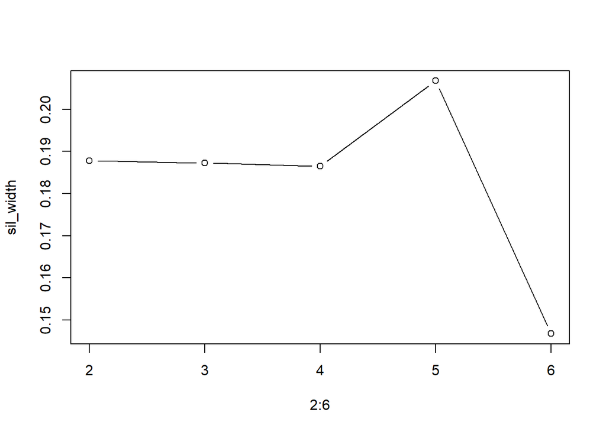

```r
#silhouette method

library(cluster)

sil_width <- numeric(length = 5)

# Computing silhouette widths for different numbers of clusters
for (k in 2:6) {
  # Perform K-means clustering
  kmeans_model <- kmeans(scaled_time_data, k, nstart = 10)

  if (k > 1) {  # Silhouette width using two clusters
    silhouette_width <- silhouette(kmeans_model$cluster, dist(scaled_time_data))
    sil_width[k - 1] <- mean(silhouette_width[, "sil_width"])
  }
}

# Plot the silhouette scores
plot(2:6, sil_width, type = "b")
```

```r
#2. Show the membership for each cluster
optimal_num_clusters <- 5

#K-means clustering with the optimal number of clusters
kmeans_model <- kmeans(scaled_time_data, optimal_num_clusters, nstart = 10)

cluster_membership <- kmeans_model$cluster

# Print the cluster membership for each data point
print(cluster_membership)
```

```
##  [1] 1 5 5 5 3 5 5 5 5 3 3 3 3 3 2 5 5 3 5 4 3
```

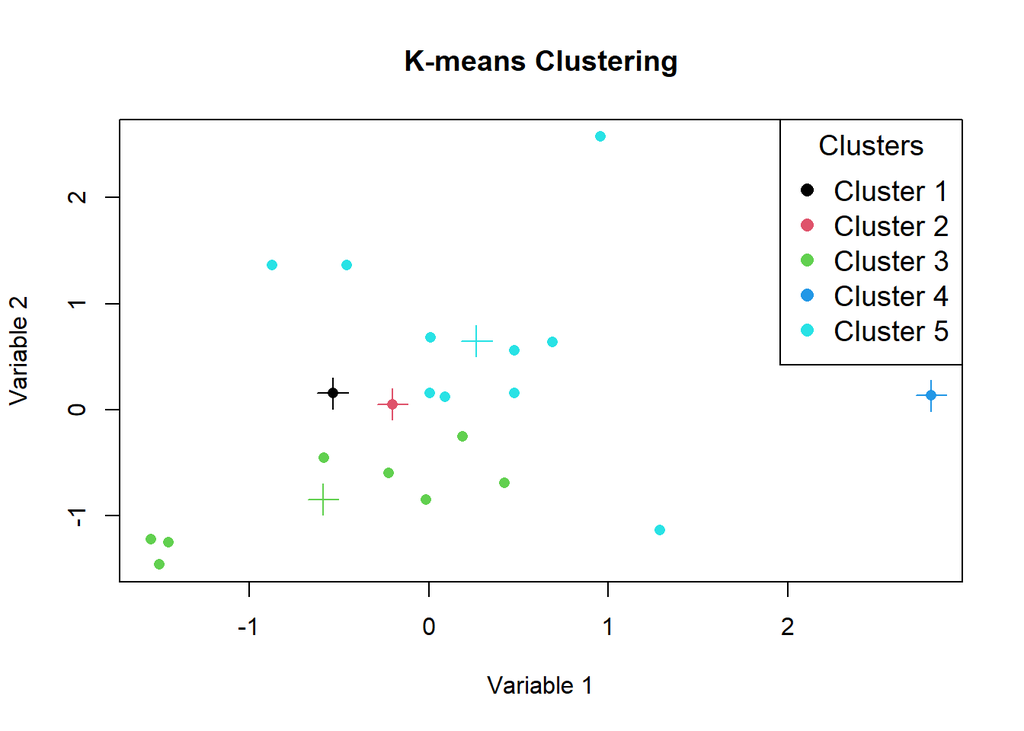

```r
# Scatter plot of the data with clusters colored by membership
plot(scaled_time_data[, 1], scaled_time_data[, 2],
     col = kmeans_model$cluster, pch = 16,
     xlab = "Variable 1", ylab = "Variable 2",
     main = "K-means Clustering")

# Adding cluster centers to the plot
points(kmeans_model$centers[, 1], kmeans_model$centers[, 2], col = 1:optimal_num_clusters, pch = 3, cex = 2)

# Adding legend
legend("topright", legend = paste("Cluster", 1:optimal_num_clusters), col = 1:optimal_num_clusters, pch = 16, cex = 1.2, title = "Clusters")
```

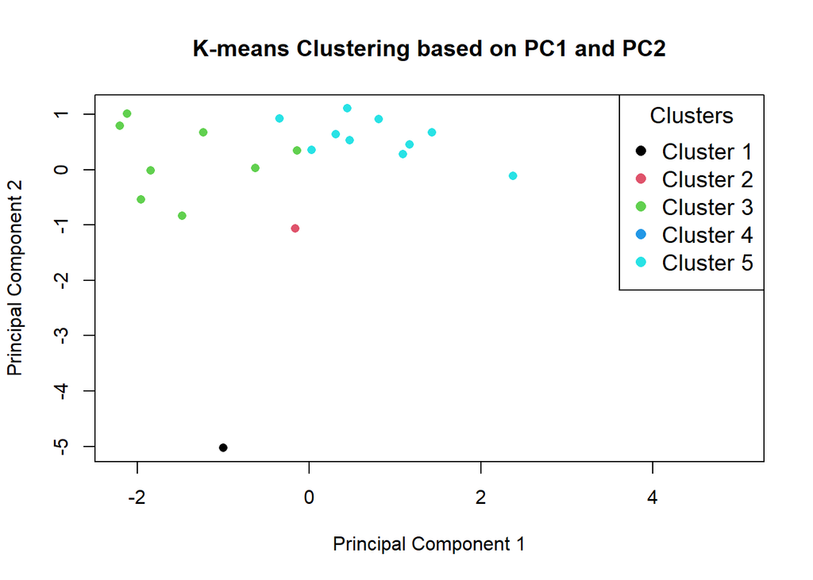

```r
#3. Show a visualization of the cluster and membership using the first two Principal Components.

# Perform PCA
pca_result <- prcomp(scaled_time_data, scale. = TRUE)

# Extract PC scores for the first three principal components
PC1 <- pca_result$x[, 1]
PC2 <- pca_result$x[, 2]
PC3 <- pca_result$x[, 3]

# Plot the data with clusters colored by membership
plot(PC1, PC2,
     col = kmeans_model$cluster, pch = 16,
     xlab = "Principal Component 1", ylab = "Principal Component 2",
     main = "K-means Clustering based on PC1 and PC2")

# Add legend
legend("topright", legend = paste("Cluster", 1:optimal_num_clusters),
       col = 1:optimal_num_clusters, pch = 16, cex = 1.2, title = "Clusters")
```

```r
# Saving five k-means clusters in a list
# Initialize a list to store matrices for each cluster
cluster_matrices <- list()

# Iterate over each cluster
for (i in 1:max(kmeans5.sm$cluster)) {
     # Subset data for the current cluster
     cluster_indices <- which(kmeans5.sm$cluster == i)
     cluster_data <- scaled_time_data[cluster_indices, ]

     # Store the cluster data in the list
     cluster_matrices[[paste0("clus", i)]] <- cluster_data
 }

# Check the list of matrices
print(cluster_matrices)
```

```
## $clus1
## Instagram_Time  Linkedin_Time  Snapchat_Time   Twitter_Time  Whatsapp_Time
##    -0.20307694     0.05089913     0.06669404    -0.44951033     0.04200212
##   Youtube_Time       OTT_Time    Reddit_Time
##     0.09250226    -0.12579743     4.06616195
##
## $clus2
##      Instagram_Time Linkedin_Time Snapchat_Time Twitter_Time Whatsapp_Time
## [1,]    -1.54900425    -1.2283925    -0.7126766   0.06702685    -0.8323915
## [2,]    -1.50076313    -1.4640515    -0.7126766  -0.44951033    -1.3320450
## [3,]    -0.22237339    -0.6022129    -0.4834499   1.42293695    -1.3320450
## [4,]    -0.58418181    -0.4540844    -0.5292952   1.74577269    -0.6658403
## [5,]    -0.01483606    -0.8496548    -0.3711289  -0.44951033    -0.5773600
## [6,]     0.18767615    -0.2520910    -0.1625326   0.32529544    -0.7282970
## [7,]     0.41923354    -0.6897434     0.3142588  -0.44951033     0.1544242
## [8,]    -1.45252201    -1.2553249    -0.7126766  -0.44951033     0.0000000
##      Youtube_Time    OTT_Time Reddit_Time
## [1,]   0.30354444 -0.10219460   0.2985977
## [2,]   0.01575964 -0.66866236  -0.3293296
## [3,]  -1.13537955 -0.66866236  -0.3293296
## [4,]  -0.27202515 -0.24381154  -0.3293296
## [5,]  -1.39918228 -0.52409507  -0.3206084
## [6,]  -0.27202515 -0.38542848  -0.3293296
## [7,]  -1.25049347  0.02998121  -0.3293296
## [8,]  -1.71094914 -0.66866236  -0.3293296
##
## $clus3
## Instagram_Time  Linkedin_Time  Snapchat_Time   Twitter_Time  Whatsapp_Time
##     -0.5359407      0.1518958     -0.1625326      3.4245185     -1.3320450
##   Youtube_Time       OTT_Time    Reddit_Time
##     -0.2720252      3.4382289      1.2404888
##
## $clus4
## Instagram_Time  Linkedin_Time  Snapchat_Time   Twitter_Time  Whatsapp_Time
##      2.7975209      0.1316965      3.3125433     -0.4495103      2.2529688
##   Youtube_Time       OTT_Time    Reddit_Time
##      1.2628271      2.1636764     -0.3293296
##
## $clus5
##       Instagram_Time Linkedin_Time Snapchat_Time Twitter_Time Whatsapp_Time
##  [1,]    0.689383825     0.6366800   1.313686989   -0.4495103   -0.53676316
##  [2,]   -0.458754888     1.3638563  -0.419266450   -0.4495103    0.87475793
##  [3,]    0.009183999     0.6838118   0.002510578   -0.4495103   -0.25778997
##  [4,]   -0.873628541     1.3638563  -0.455942713   -0.4495103    1.41604920
##  [5,]    0.004359887     0.1518958  -0.712676556   -0.4495103   -0.08291125
##  [6,]    0.477122887     0.1518958   0.937755290   -0.4495103    0.91639572
##  [7,]    0.954709998     2.5758168   1.396208581   -0.4495103   -0.04543724
##  [8,]    0.477122887     0.5558827  -0.483449910   -0.4495103   -0.33273799
##  [9,]    1.287573743    -1.1408620  -0.712676556   -0.2428955    1.75331530
## [10,]    0.091193907     0.1182303  -0.712676556   -0.4495103    0.64575008
##       Youtube_Time   OTT_Time Reddit_Time
##  [1,]   0.73522164 -0.6686624 -0.32932963
##  [2,]  -0.64614539 -0.1021946 -0.32932963
##  [3,]  -0.55980995 -0.1021946 -0.32932963
##  [4,]   2.31803803  0.1810393 -0.32932963
##  [5,]   0.01575964 -0.6686624 -0.32932963
##  [6,]  -0.55980995  0.1810393 -0.32932963
##  [7,]   0.59132924  0.1810393 -0.32932963
##  [8,]   1.16689883 -0.3854285 -0.01536595
##  [9,]   0.32273009 -0.1918853 -0.32932963
## [10,]   1.25323427 -0.6686624 -0.32932963
```